# job_analysis

## 岗位分析的目的

常做岗位分析，面试不会心虚。 ——鲁迅

这次的岗位分析主要目的如下：

- 了解目前市场需求
- 分析目前是不是值得跳槽
- 了解目标岗位的职责&要求&薪资水平
- 分析目前值得跳槽的行业
- 锁定高度感兴趣公司&岗位
- 分析工资多少比较合适
- 确定在面试前需要着重复习&学习的知识点
- 增加项目分析经验
- 制作通用分析模板&工具

## 就业市场需求

### 分析思路：

岗位需求最好的量化标准是利用招聘网站的后台数据，通过不同岗位在一定时间内的发布数量趋势，得到该岗位的相对市场需求状态。

由于此类数据较难获取，因此本次分析换个思路。理论上，岗位的热度和岗位的需求呈正比，符合供求关系。岗位的热度是来自于供求双方的，因此使用常用的“百度指数”以及“微信指数”等工具，可以比较客观地看到目前岗位的热度，从而推断出岗位目前的相对市场需求。

### 分析结果：

#### 就业市场热度

对于大部分人来讲，招聘软件不是常用软件。只有在需要求职的时候才会点开，或者搜索下载。 因此招聘软件的热度直接反映了招聘市场的热度。

[figure not shown]

参考网址：https://index.baidu.com/v2/main/index.html#/trend/boss直聘?words=boss直聘,拉勾,猎聘,前程无忧,智联招聘

从招聘软件的搜索热度上看，每年春招开始会飙升到当年的顶峰，然后开始急剧下落，大约持续1-2个月时间，符合直观感受。 然而秋招并不见得有多热门，实际上秋招的热度并不如春招以后一直持续到秋招前1个月的热度。 可简单理解为，春招并未获得称心offer的老哥们会持续参加招聘，而秋招更多的是毕业生带起来的热度。

##### 结论1

每年最值得跳槽的时机是春招期间。

#### 岗位热度

[figure not shown]

参考网址：https://index.baidu.com/v2/main/index.html#/trend/数据分析师?words=数据分析师,产品经理,金融科技,风险分析,增长黑客

数据显示，岗位热度和招聘跟随招聘季节展示周期性变化，符合直观感受。

##### 假设1

岗位的搜索热度与岗位的市场需求成正比。

##### 假设2

若两个岗位的搜索热度相当，则代表市场对应的岗位相当。

产品经理作为互联网公司标配，其热度可以被定义为基准值。 而产品经理从18年年中至今呈现下降趋势，暂时理解为产品经理已经成为了标配，热度不如之前，同时互联网不断新增各种职位，也会同时把部分产品经理岗位转化。

从数据上看，数据分析师的岗位热度符合招聘周期。 其在18年年中的异常飙升后，恢复到17年至今的平均水平附近。 目前数据分析师的岗位热度约产品经理的80%。

出乎意料的是，金融分析师的岗位热度也有数据分析师的60%，而且从17年至今总体热度比较均衡。 虽然也有跟随招聘周期波动，但是波动幅度较小，因此供求关系并不会因为招聘旺季而急剧变化。 从常识上推断，此岗位对于金融背景和经历有较高要求，而且金融行业属于传统行业。

增长黑客其实出现的时间已经不短了，但是从热度上看，其爆发的时间是19年的秋招，并且今年还没到春招，热度已经高于金融分析师。 因此，今年增长黑客可能出现僧多粥少的情况，谨慎乐观。

###### 结论2

今年春招，数据分析师招聘热度应该跟随招聘周期波动，但是不会出现供求关系的急剧变化，因此优先级应该高于金融分析师和增长黑客。

#### 岗位发布情况

此数据只能说明大部分公司在17号以后才复工，并不具备太大意义。 此外，拉勾数据较少，且并不存在大量年前数据，可能由于平台强制要求刷新岗位数据，因此导致了绝大部分数据都只近期的。 故，不能以发布岗位的频数分布来判断近期热度。

```python
import pandas as pd
import seaborn as sns
import matplotlib.pyplot as plt
import matplotlib as mpl
from matplotlib.font_manager import FontProperties
import wordcloud as wc
import jieba as jb
from string import punctuation
```

```python
# setting
my_font = FontProperties(fname=r"/System/Library/Fonts/STHeiti Medium.ttc",size=10)
sns.set(style="dark", context="notebook", font=my_font.get_name())
%matplotlib inline
```

```python
# read data
job_table = pd.read_csv(r"/Users/llx/PyProjects/job_wizard/数据分析师_20200222.csv")
```

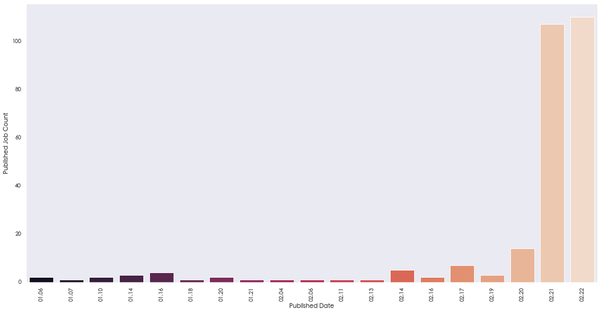

```python
# Question 1
# How many of them were published in last week?
publish_cnt = job_table.groupby(["Add_Date"], as_index=False)["Path"].count().rename(columns={"Path": "count"})
publish_cnt2 = publish_cnt[publish_cnt["Add_Date"] >= 20200101]
publish_cnt2["date"] = pd.to_datetime(publish_cnt2["Add_Date"], format="%Y%m%d").dt.strftime("%m.%d")
plt.figure(figsize=(20,10))
plot_publish = sns.barplot(x="date", y="count", data=publish_cnt2, palette="rocket")
plot_publish.set_xticklabels(plot_publish.get_xticklabels(), rotation=90)
plt.xlabel("Published Date")
plt.ylabel("Published Job Count")
plt.show()
```

## 岗位薪资水平

### 分析思路：

通过描述性统计，来分析数据分析师的平均工资以及平均工资和行业的关系

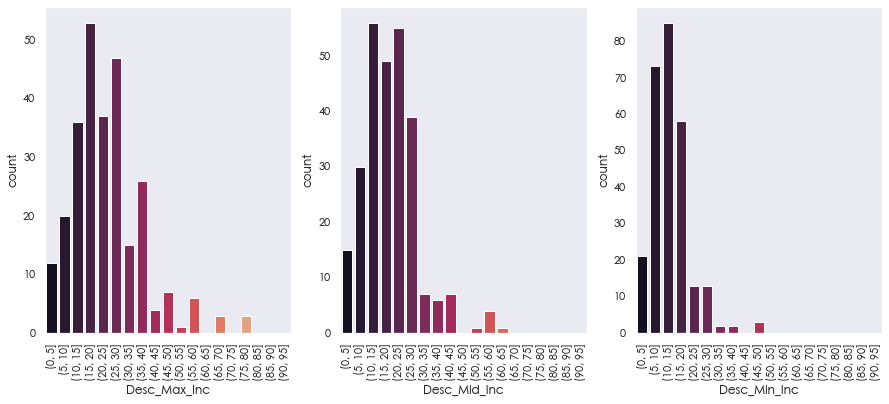

```python
# data preprocessing
salary_bins = [x*5 for x in range(20)]
income_stats = ["Max", "Mid", "Min"]

for income_stat in income_stats:
    job_table["Desc_"+income_stat+"_Inc"] = pd.cut(job_table["Income_"+income_stat+"(k)"], bins=salary_bins)

job_table["Desc_Industry"] = job_table["Industry"].str.split(",").str[0]

salary_bins = [x*5 for x in range(20)]
income_stats = ["Max", "Mid", "Min"]

salary_cnt = {}
for income_stat in income_stats:
	salary_cnt[income_stat] = job_table.groupby(["Desc_"+income_stat+"_Inc"], as_index=False)["Path"].count().rename(columns={"Path": "count"})

fig, axs = plt.subplots(1, 3, figsize=(15,6))
plot_salary = {}
for index, income_stat in enumerate(income_stats):
	plot_salary[income_stat] = sns.barplot(x="Desc_"+income_stat+"_Inc", y="count", data=salary_cnt[income_stat], palette="rocket", ax=axs[index])
	plot_salary[income_stat].set_xticklabels(plot_salary[income_stat].get_xticklabels(), rotation=90)

plt.show()
```

#### 总体岗位平均工资：

##### 假设3

以岗位薪资的中间值作为岗位的实际工资

##### 结论3

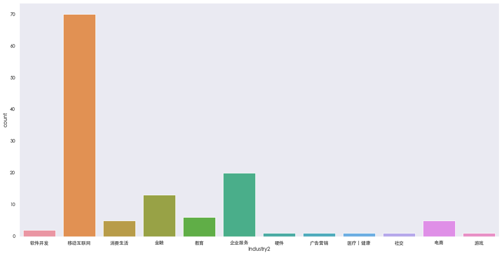

```python
def industry_clean(my_text):
    if "," in my_text:
        return my_text.split(",")[0]
    elif "|" in my_text:
        return my_text.split("|")[0]

job_table["Industry2"] = job_table["Industry"].apply(industry_clean)
industry_cnt = job_table.groupby(["Industry2"], as_index=False)["Path"].count().rename(columns={"Path": "count"}).sort_values(["count"], ascending=False)
industry_cnt[industry_cnt["count"]>1]

plt.figure(figsize=(20,10))
plot_industry = sns.countplot(x="Industry2", data=job_table)
```

##### 行业分布

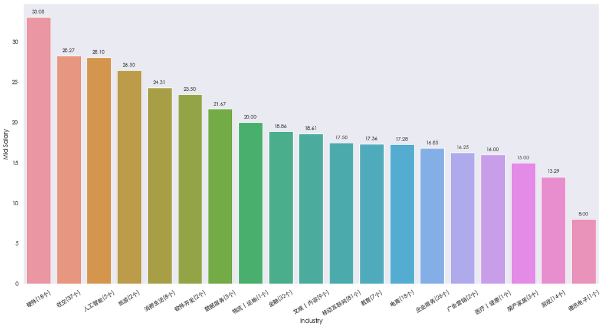

```python
job_table["Industry"].unique().tolist()
unique_industry = job_table["Desc_Industry"].unique().tolist()
industry_cnt = job_table.groupby(["Desc_Industry"], as_index=False)["Income_Mid(k)"].agg(["count","mean"]).reset_index().sort_values(["mean"], ascending=False)
industry_cnt["Desc_Industry2"] = industry_cnt["Desc_Industry"] + "(" + industry_cnt["count"].astype(str) + "个)"

plt.figure(figsize=(20,10))
plot_industry = sns.barplot(x="Desc_Industry2", y="mean", data=industry_cnt)

for p in plot_industry.patches:
	plot_industry.annotate(format(p.get_height(), ".2f"), (p.get_x() + p.get_width() / 2., p.get_height()), ha = "center", va = "center", xytext = (0, 10), textcoords = "offset points")

plot_industry.set_xticklabels(plot_industry.get_xticklabels(), rotation=30)

plt.xlabel("Industry")
plt.ylabel("Mid Salary")
plt.show()
```

##### 行业薪资水平

从数据上看，硬件行业公司（OPPO、VIVO、华为）提供的薪水远超其他行业。 而互联网行业虽然岗位众多，但是薪资水平低于行业平均水平。 其次，金融行业提供的薪酬水平也仅处在中游，并不尽如人意。

###### 结论

薪资水平较高的行业为：硬件、人工智能、社交。

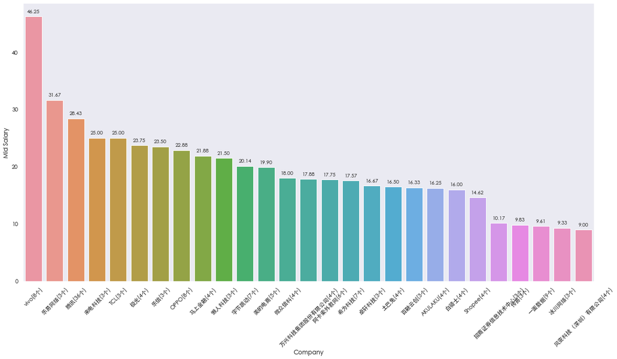

```python
job_table["Company"].unique().tolist()
company_mean = job_table.groupby(["Company"])["Income_Mid(k)"].agg(["count","mean"]).reset_index().sort_values(["mean"], ascending=False)
company_cnt = company_mean[company_mean["count"]>2]
company_cnt["Desc_Company"] = company_cnt["Company"] + "(" + company_cnt["count"].astype(str) + "个)"

plt.figure(figsize=(20,10))
plot_company = sns.barplot(x="Desc_Company", y="mean", data=company_cnt)

for p in plot_company.patches:
    plot_company.annotate(format(p.get_height(), ".2f"), (p.get_x() + p.get_width() / 2., p.get_height()), ha = "center", va = "center", xytext = (0, 10), textcoords = "offset points")

plot_company.set_xticklabels(plot_company.get_xticklabels(), rotation=45)

plt.xlabel("Company")
plt.ylabel("Mid Salary")
plt.show()
```

##### 公司薪资水平

作为互联网银行的第一集团，微众银行值得留意。

###### 结论

先把范围圈定在VIVO，OPPO，腾讯

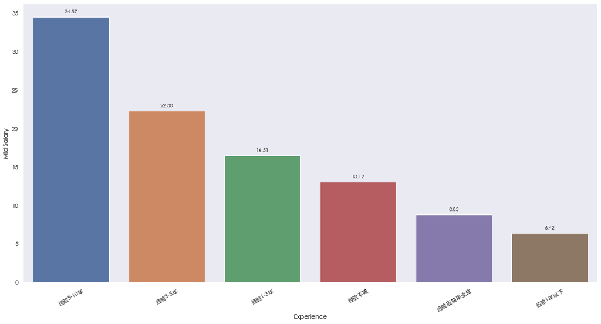

```python
job_table["Experience"].unique().tolist()
experience_cnt = job_table.groupby(["Experience"])["Income_Mid(k)"].agg(["count","mean"]).reset_index().sort_values(["mean"], ascending=False)

plt.figure(figsize=(20,10))
plot_experience = sns.barplot(x="Experience", y="mean", data=experience_cnt)

for p in plot_experience.patches:
    plot_experience.annotate(format(p.get_height(), ".2f"), (p.get_x() + p.get_width() / 2., p.get_height()), ha = "center", va = "center", xytext = (0, 10), textcoords = "offset points")

plot_experience.set_xticklabels(plot_experience.get_xticklabels(), rotation=30)

plt.xlabel("Experience")
plt.ylabel("Mid Salary")
plt.show()
```

##### 工作经验与薪资关系

工作经验越丰富，薪资水平越高。 5-10年工作经验的职场人士，薪资水平较3-5年的人会有较大幅度增长，超过50%。

```python
import numpy as np
import pyLDAvis
from biterm.cbtm import oBTM
from sklearn.feature_extraction.text import CountVectorizer
from biterm.utility import vec_to_biterms, topic_summuary # helper functions

jb_text_list = job_table["Description"].tolist()

stopwords1 = [line.strip() for line in open(r"/Users/llx/PyProjects/job_wizard/stopwords-master/中文停用词表.txt", 'r', encoding='utf-8').readlines()]
stopwords2 = [line.strip() for line in open(r"/Users/llx/PyProjects/job_wizard/stopwords-master/哈工大停用词表.txt", 'r', encoding='utf-8').readlines()]
stopwords3 = [line.strip() for line in open(r"/Users/llx/PyProjects/job_wizard/stopwords-master/四川大学机器智能实验室停用词库.txt", 'r', encoding='utf-8').readlines()]
stopwords4 = [line.strip() for line in open(r"/Users/llx/PyProjects/job_wizard/stopwords-master/百度停用词表.txt", 'r', encoding='utf-8').readlines()]
stopwords = list(dict.fromkeys(stopwords1 + stopwords2 + stopwords3 + stopwords4))
stopwords = stopwords.append(['任职资格','工作职责','岗位职责','职位要求','任职要求','计算机','数学','年度体检','五险一金','每月聚餐','工资','生日礼物等','零食饮料','关于我们'])

# vectorize texts
vec = CountVectorizer(stop_words=stopwords)
X = vec.fit_transform(jb_text_list).toarray()
# get vocabulary
vocab = np.array(vec.get_feature_names())
# get biterms
biterms = vec_to_biterms(X)
# create btm
btm = oBTM(num_topics=20, V=vocab)
```

```python
print("\n\n Train Online BTM ..")
for i in range(0, len(biterms), 100):
    biterms_chunk = biterms[i:i + 100]
    btm.fit(biterms_chunk, iterations=50)
topics = btm.transform(biterms)
```

```
 Train Online BTM ..
```

```python
print("\n\n Visualize Topics ..")
vis = pyLDAvis.prepare(btm.phi_wz.T, topics, np.count_nonzero(X, axis=1), vocab, np.sum(X, axis=0))
pyLDAvis.save_html(vis, 'online_btm.html')
```

```
 Visualize Topics ..
```

```python
print("\n\n Topic coherence ..")
topic_summuary(btm.phi_wz.T, X, vocab, 10)
```

```
 Topic coherence ..
Topic 0 | Coherence=-95.58 | Top words= 岗位职责 任职要求 统计学 任职资格 各种趴体约你玩 婚假 we 年度体检 节日假期和节日礼包 团结
Topic 1 | Coherence=-71.14 | Top words= 岗位职责 任职要求 数学 r语言 spss 熟练掌握hive spark python 计算机 熟练掌握sql语言
Topic 2 | Coherence=-91.51 | Top words= 任职要求 本科及以上学历 python 岗位职责 hive 计算机 对数据敏感 职责描述 岗位要求 工作内容
Topic 3 | Coherence=-52.60 | Top words= 本科及以上学历 负责专项分析并形成数据分析报告 建立渠道质量评估模型 分析和解决问题 计算机 岗位职责 负责构建渠道分析体系 反作弊系统 设计并优化防作弊 反作弊
Topic 4 | Coherence=-53.84 | Top words= 岗位职责 任职资格 就近地铁站是汉溪长隆以及广州南站 工作地点 佛山顺德北滘美的全球创新中心 近广州番禺 公司有员工宿舍以及免费上下班车提供 广州地铁顺德段即将通车 本科以上学历 了解python
Topic 5 | Coherence=-101.25 | Top words= 任职要求 数学 python 本科及以上学历 工作职责 统计 211本科及以上学历 熟悉sql 能结合产品团队的需求完成建模分析 具备较强的数据敏感度
Topic 6 | Coherence=-90.65 | Top words= 岗位职责 任职资格 数学 统计 全日制本科及以上学历 搭建风险监测系统 负责风险数据收集 掌握python 分析 岗位要求
Topic 7 | Coherence=-16.28 | Top words= 任职要求 既有情怀 合理的工作时间 不提倡加班 又有 每月聚餐 每周的篮球和羽毛球运动 每周分享会 以后能去得更远 我们有弹性工作时间制度
Topic 8 | Coherence=-84.01 | Top words= 岗位职责 本科及以上学历 熟悉python hive 精通sql hadoop 任职资格 用户分群 职位要求 自我驱动
Topic 9 | Coherence=-50.37 | Top words= 岗位要求 岗位职责 spark 良好的统计分析基础 有广告相关背景优先 数据挖掘算法 较高的数据敏感性 善于沟通 工作积极主动 hadoop
Topic 10 | Coherence=-89.06 | Top words= 岗位职责 岗位要求 较强的数据分析能力 工作职责 python hive 本科以上学历 报表开发及可视化呈现 完成数据分析 任职要求
Topic 11 | Coherence=-73.20 | Top words= 计算机 数学 统计 hadoop hive 岗位职责 任职要求 规划搭建数据指标体系和分析体系 对数据敏感 数据分析
Topic 12 | Coherence=-82.21 | Top words= 数学 岗位职责 统计学 统计 产品 岗位要求 任职资格 本科以上学历 计算机 职位要求
Topic 13 | Coherence=-64.04 | Top words= 任职资格 数学 工作职责 large data in communication are from experience
Topic 14 | Coherence=-56.55 | Top words= 数学 岗位职责 任职资格 整理 担当能力 发挥数据引领业务的作用 较高的责任心 良好的沟通表达 依托数据仓库进行数据的提取 跟踪评价
Topic 15 | Coherence=-73.76 | Top words= 岗位职责 岗位要求 利用数据分析和数据可视化 准备到模型实现和商业洞察 从数据收集 计算机 聚类 任职要求 让数据在业务中发挥更大的价值 探索数据产品化的机会
Topic 16 | Coherence=-99.31 | Top words= 岗位职责 任职要求 数学 本科及以上学历 良好的团队合作精神 统计 信息传播等方面 三年以上互联网数据挖掘和应用相关工作经验 结合前沿的研究成果 用机器学习
Topic 17 | Coherence=-84.36 | Top words= 统计学 本科及以上学历 任职要求 熟练使用excel 工作职责 岗位职责 通过数据分析 职位要求 能承受一定的工作压力 数学
Topic 18 | Coherence=-79.48 | Top words= 岗位职责 岗位要求 数学 hadoop python 如hive mysql sas 统计学 对数据敏感
Topic 19 | Coherence=8.35 | Top words= want 深圳户口 市场估值10亿人民币 丧假 blaze cto 导师一对一带教 如果您对自己的能力充满自信 以上游戏仅限海外市场发行 我们完成了a轮融资
```

[output not shown]

##### JD分析

###### 假设

JD当中所有的关键字都是对于岗位的要求

Topic 16：数据分析师有学历和经验要求，并且需要学习前沿研究结果和掌握机器学习算法。另外，也强调了数据分析师需要有较强的沟通能力。

Topic 0：数据分析师需要有统计学背景，且互联网公司喜欢强调福利。

Topic 2：数据分析师需要有本科以上学历，且掌握Python，Hive。此外， 还需要对数据敏感。

Topic 6：数据分析师需要有本科以上学历，需要搭建数据系统，负责数据收集，且掌握Python

###### 结论

互联网公司对于数据分析师的要求：

1. 本科及以上学历，且有数学和统计学背景要求
2. 掌握SQL、Python和Hive
3. 需要对数据敏感
4. 有沟通合作能力

```python
print("\n\n Texts & Topics ..")
for i in range(len(jb_text_list)):
    print("{} (topic: {})".format(jb_text_list[i], topics[i].argmax()))
```

[output not shown]

[output cut: 3621 more lines]

[output not shown]

```python
def jb_flag(jb_text,jb_flag):
    if jb_flag in jb_text.lower():
        return 1
    else:
        return 0

job_flag = job_table[["Description","Company"]]

flag_list = {
"if_ml":"机器学习"
,"if_dm":"数据挖掘"
,"if_hadoop":"hadoop"
,"if_sql":"sql"
,"if_sas":"sas"
,"if_spark":"spark"
,"if_behv":"用户行为"
,"if_cust":"客户画像"
,"if_model":"建模"
,"if_algo":"算法"
,"if_exp":"相关经验"
,"if_big":"大数据"
,"if_hive":"hive"
,"if_hsql":"hsql"
}

for item in flag_list:
    job_flag[item] = job_flag["Description"].apply(jb_flag, args=[flag_list[item]])
```

```python
total=job_flag["Company"].count()
print("出现比例：")
jb_valid = []
for item in flag_list:
    jb_valid.append({
        "flag":flag_list[item],
        "occurence":job_flag[item].sum(),
        "total_jb":total,
        "pct":job_flag[item].sum()/total
    })
job_valid = pd.DataFrame(jb_valid)
job_valid.sort_values(["pct"], ascending=False)
```

```
出现比例：
```

|  | flag | occurence | total_jb | pct |
| --- | --- | --- | --- | --- |
| 3 | sql | 177 | 270 | 0.655556 |
| 1 | 数据挖掘 | 97 | 270 | 0.359259 |
| 8 | 建模 | 88 | 270 | 0.325926 |
| 12 | hive | 65 | 270 | 0.240741 |
| 9 | 算法 | 64 | 270 | 0.237037 |
| 2 | hadoop | 55 | 270 | 0.203704 |
| 4 | sas | 55 | 270 | 0.203704 |
| 11 | 大数据 | 53 | 270 | 0.196296 |
| 0 | 机器学习 | 45 | 270 | 0.166667 |
| 5 | spark | 42 | 270 | 0.155556 |
| 6 | 用户行为 | 40 | 270 | 0.148148 |
| 10 | 相关经验 | 29 | 270 | 0.107407 |
| 13 | hsql | 2 | 270 | 0.007407 |
| 7 | 客户画像 | 1 | 270 | 0.003704 |

##### 验证JD分析

通过增加标签，得到SQL确实是数据分析师最核心的工具，超过65%的岗位要求掌握SQL。 此外,目前约1/3数据分析岗位都会要求掌握数据挖掘和建模相关技能。 HIVE和Hadoop的要求也超过了20%。

###### 结论

需要尽快补充的的面试知识：

1. 常用数据挖掘算法（应用场景，优缺点，基本逻辑）
2. Hive/HQL入门知识
3. Hadoop基本架构
4. 项目经验：把本分析代码完善，定期输出报告
5. 项目经验：开发JB分类器，区分岗位是否感兴趣